# Relatório Parcial OE1

## 1 Perguntas de pesquisa

> **OE1.1 Como evoluiu a participação do Brasil no turismo internacional entre 2010 e 2024 em comparação a destinos concorrentes?**

> **OE1.2 Há diferenças na evolução da participação do Brasil em mercados emissores mais sensíveis às mudanças climáticas?**

> **OE1.3 Quais fatores estruturais e conjunturais explicam variações no desempenho do Brasil em termos de chegadas e receitas?**

> **OE1.4 Em que medida choques externos (megaeventos, recessões, pandemia) afetaram a competitividade internacional do turismo brasileiro?**

## 2 Estrutura do relatório

**1. Participação do Brasil no Turismo Internacional**

> Descrição da evolução da participação do Brasil e concorrentes

> Decomposição shift-share (dinâmico) da participação do Brasil e seus principais concorrentes no receptivo turístico internacional (chegadas e receitas)

**2. Participação dos países prioritários e sensíveis às mudanças climáticas no Turismo Internacional**

> Descrição da evolução da participação dos países no emissivo mundial (saídas e gastos)

> Decomposição shift-share (dinâmico) da participação desses países no emissivo turístico internacional (saídas e gastos)

> Descrição da evolução da participação do Brasil no emissivo internacional desses países

**3. Avaliação do efeito de choques externos sobre a participação do Brasil no Turismo Internacional**

> Descrição dos choques (Copa-2014, Rio-2016, recessão-2015, pandemia-2020)

> Event-study

**4. (TALVEZ) Fatores estruturais e conjunturais que afetaram a participação**

## 3 Participação do Brasil no Turismo Internacional

### 3.1 Evolução da participação do Brasil e de concorrentes

#### 3.1.1 Mundo e Brasil

Em relação ao mundo:

- Crescimento contínuo entre 2010 e 2019.
- Grande interrupção por conta da pandemia de covid-19.
- Forte retomada em 2022.
- Em 2024 retomou o número de viagens de 2019.

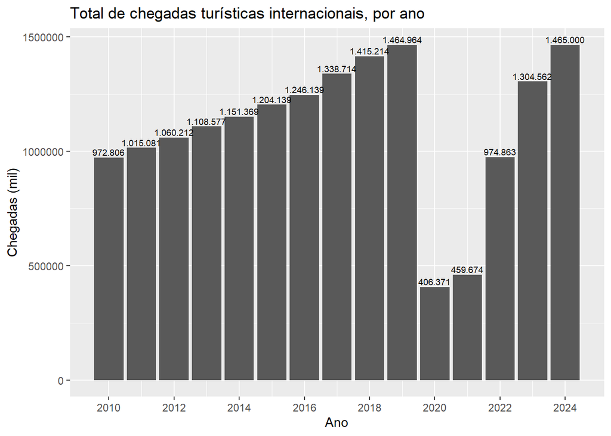

**WarningAlerta sobre crescimento recente do Brasil**

Tenho a impressão de que o Brasil mudou a forma de calcular o volume de chegadas anual após a pandemia. Antes da pandemia o MTUR tinha técnicos que se dedicavam a essa estimativa e dados de apoio secundários da apoio, que ajudavam a refinar os dados provenientes da Polícia Federal. Acho que após a pandemia esses recursos praticamente desapareceram e os dados passaram a se basear somente no que a Polícia Federal entrega. Ressalto que isso é só uma leitura minha da situação. Deixo isso escrito aqui para tomarmos cuidado com a análise dos resultados recentes do Brasil - acho que não devemos nos empolgar com o crescimento recente sem ter mais certeza de que ele é real.

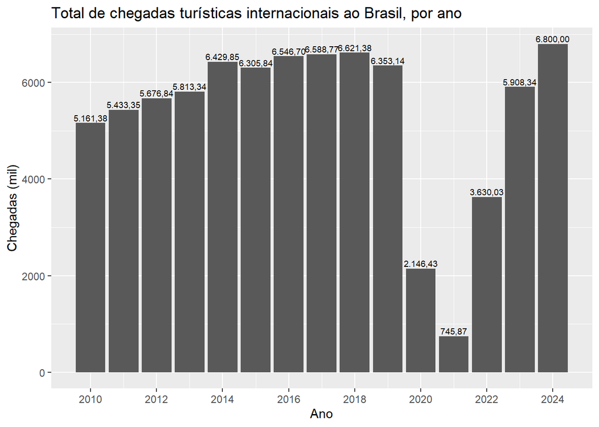

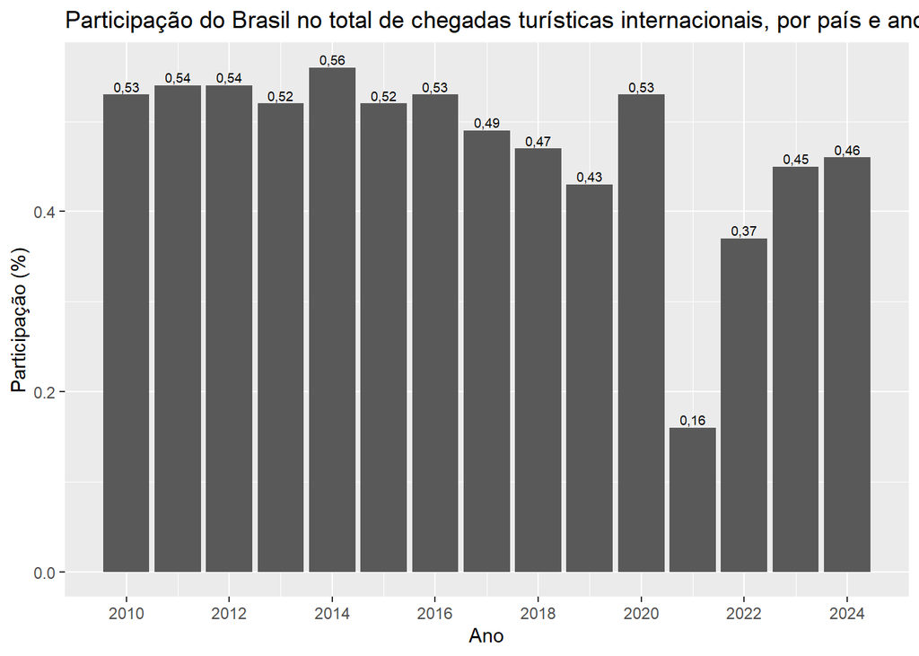

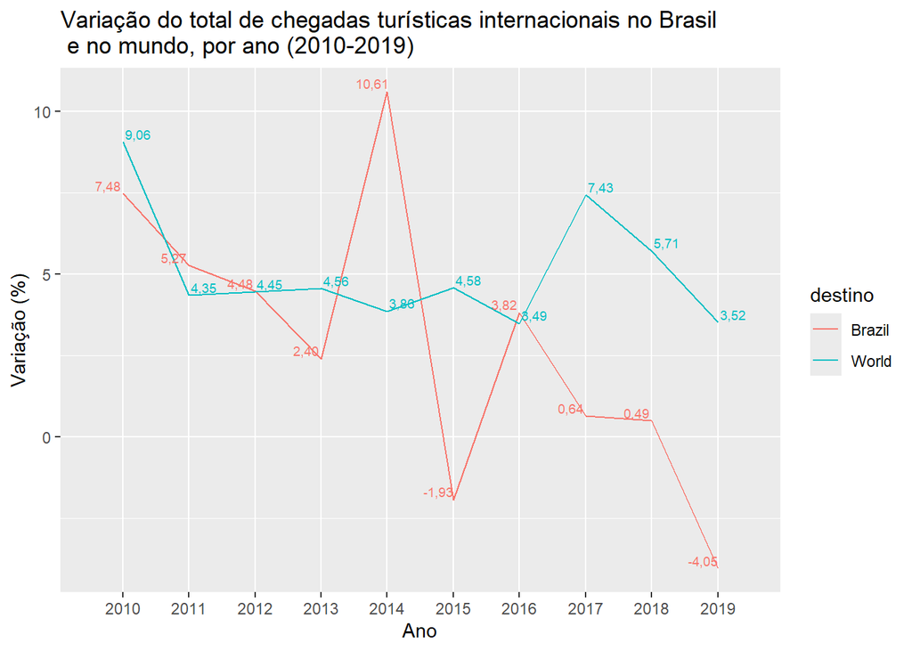

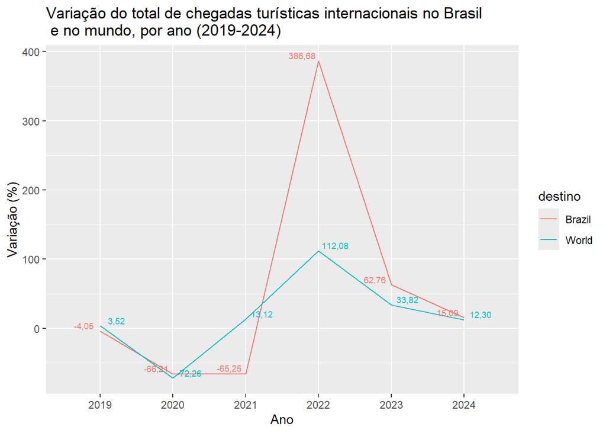

#### 3.1.2 Brasil e concorrentes

- Dez concorrentes do Brasil foram selecionados para uma análise comparativa: Peru, República Dominicana, Colômbia, Espanha, Chile, Costa Rica, Jamaica, Cuba, Argentina e Mexico.

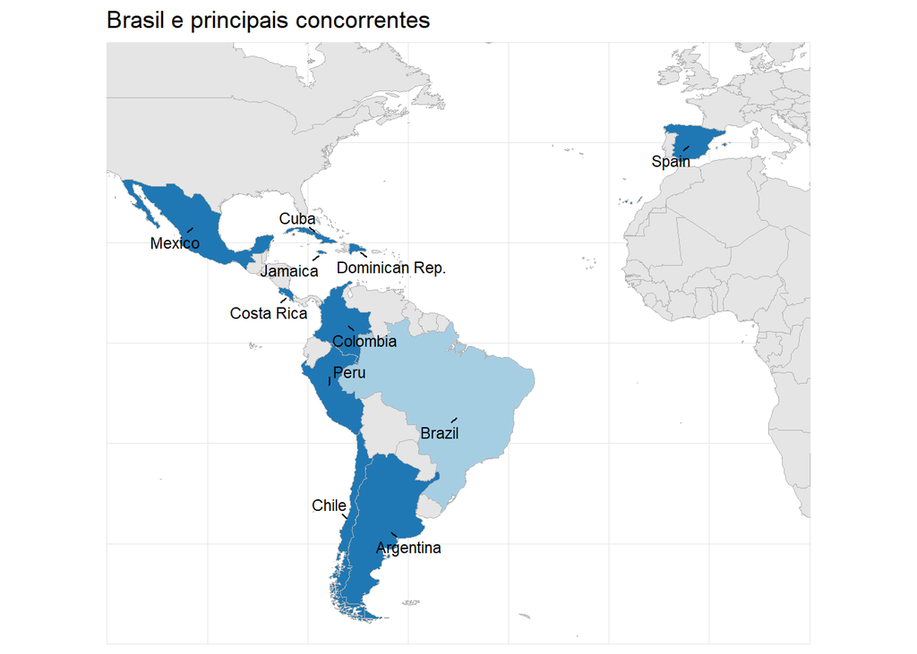

- A Espanha e, em segundo lugar, o México claramente destoam dos demais países deste grupo em termos de volume de chegadas internacionais.

[figure not shown]

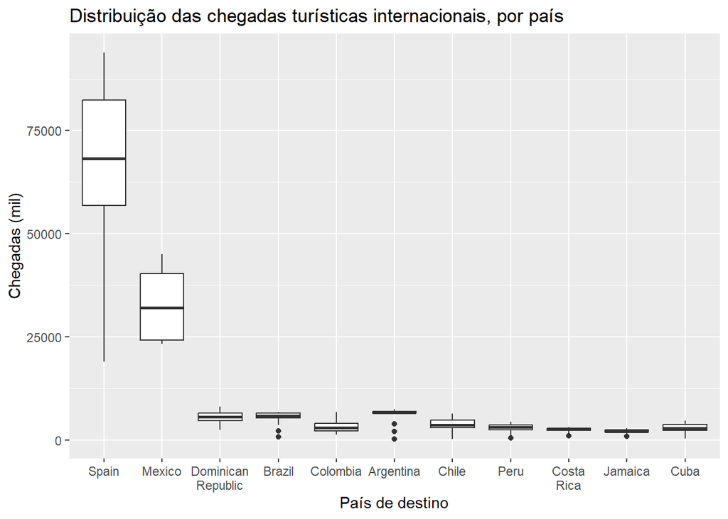

- O gráfico a seguir mostra o ranking destes países ao longo do tempo. Nota-se o Brasil majoritariamente na quarta posição, abaixo da Argentina e acima da República Dominicana.

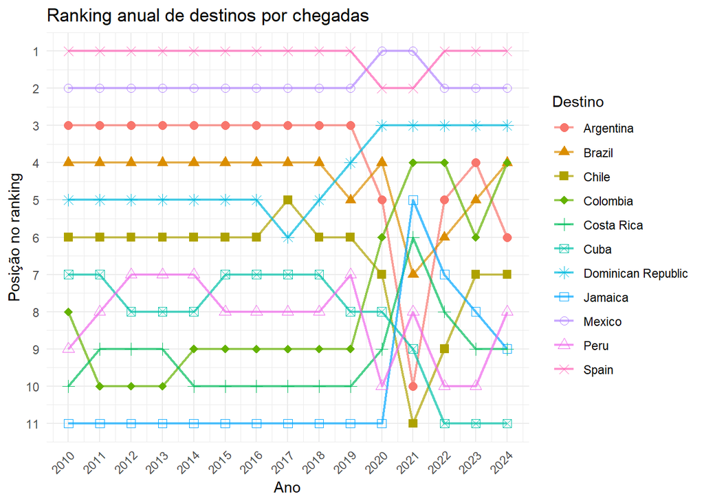

- Em 2024 o Brasil recebeu 6,8 milhões de visitantes, o mesmo número estimado pela ONU Turismo para a Colômbia e muito próximo do valor para a Argentina (6,6 milhões).
- Para o Brasil, 6,8 milhões representa o recorde da série histórica.
- O Brasil tem a quinta maior média de chegadas entre os 11 países analisados.

Chegadas turísticas internacionais, por país e ano (mil)

| destino | 2010 | 2011 | 2012 | 2013 | 2014 | 2015 | 2016 | 2017 | 2018 | 2019 | 2020 | 2021 | 2022 | 2023 | 2024 | Média |
| --- | --- | --- | --- | --- | --- | --- | --- | --- | --- | --- | --- | --- | --- | --- | --- | --- |
| Spain | 52.677,0 | 56.176,9 | 57.464,5 | 60.675,5 | 64.938,9 | 68.174,7 | 75.315,0 | 81.868,5 | 82.808,4 | 83.509,2 | 18.933,1 | 31.180,8 | 71.659,3 | 85.169,0 | 93.800,0 | 65.623,4 |
| Mexico | 23.289,7 | 23.403,3 | 23.402,5 | 24.150,5 | 29.345,6 | 32.093,3 | 35.079,4 | 39.290,9 | 41.312,7 | 45.024,5 | 24.283,5 | 31.860,4 | 38.325,6 | 41.949,4 | 45.000,0 | 33.187,4 |
| Argentina | 6.800,0 | 6.703,0 | 6.497,0 | 6.510,4 | 7.165,4 | 6.815,8 | 6.668,3 | 6.711,3 | 6.941,8 | 7.399,0 | 2.089,5 | 297,5 | 3.889,7 | 7.285,7 | 6.600,0 | 5.891,6 |
| Dominican Republic | 4.124,5 | 4.306,4 | 4.562,6 | 4.689,8 | 5.141,4 | 5.599,9 | 5.959,3 | 6.187,5 | 6.568,9 | 6.446,0 | 2.405,3 | 4.994,3 | 7.163,4 | 8.058,7 | 8.100,0 | 5.620,5 |
| Brazil | 5.161,4 | 5.433,4 | 5.676,8 | 5.813,3 | 6.429,9 | 6.305,8 | 6.546,7 | 6.588,8 | 6.621,4 | 6.353,1 | 2.146,4 | 745,9 | 3.630,0 | 5.908,3 | 6.800,0 | 5.344,1 |
| Chile | 2.800,6 | 3.137,3 | 3.554,3 | 3.576,2 | 3.674,4 | 4.478,3 | 5.640,7 | 6.449,9 | 5.722,9 | 4.518,0 | 1.119,1 | 190,0 | 2.030,5 | 3.730,5 | 5.200,0 | 3.721,5 |
| Colombia | 2.384,7 | 2.042,4 | 2.174,7 | 2.288,0 | 2.565,3 | 2.977,6 | 3.317,4 | 3.630,9 | 4.019,5 | 4.169,0 | 1.252,0 | 2.127,0 | 4.519,0 | 5.630,9 | 6.800,0 | 3.326,6 |
| Peru | 2.299,2 | 2.597,8 | 2.845,6 | 3.163,6 | 3.214,9 | 3.455,7 | 3.744,5 | 4.032,3 | 4.419,4 | 4.371,8 | 896,5 | 444,3 | 2.009,3 | 2.524,7 | 3.300,0 | 2.888,0 |
| Cuba | 2.507,0 | 2.688,0 | 2.823,2 | 2.838,7 | 2.980,7 | 3.506,1 | 3.975,3 | 4.593,9 | 4.683,7 | 4.263,1 | 1.084,7 | 355,5 | 1.613,4 | 2.400,0 | 2.200,0 | 2.834,2 |
| Costa Rica | 2.099,8 | 2.192,1 | 2.343,2 | 2.427,9 | 2.526,8 | 2.660,3 | 2.925,1 | 2.959,9 | 3.016,7 | 3.139,0 | 1.011,9 | 1.347,1 | 2.349,5 | 2.751,1 | 2.900,0 | 2.443,4 |
| Jamaica | 1.921,7 | 1.951,8 | 1.986,1 | 2.008,4 | 2.080,2 | 2.123,0 | 2.181,7 | 2.352,9 | 2.472,7 | 2.680,9 | 880,4 | 1.464,4 | 2.478,4 | 2.875,5 | 2.900,0 | 2.157,2 |

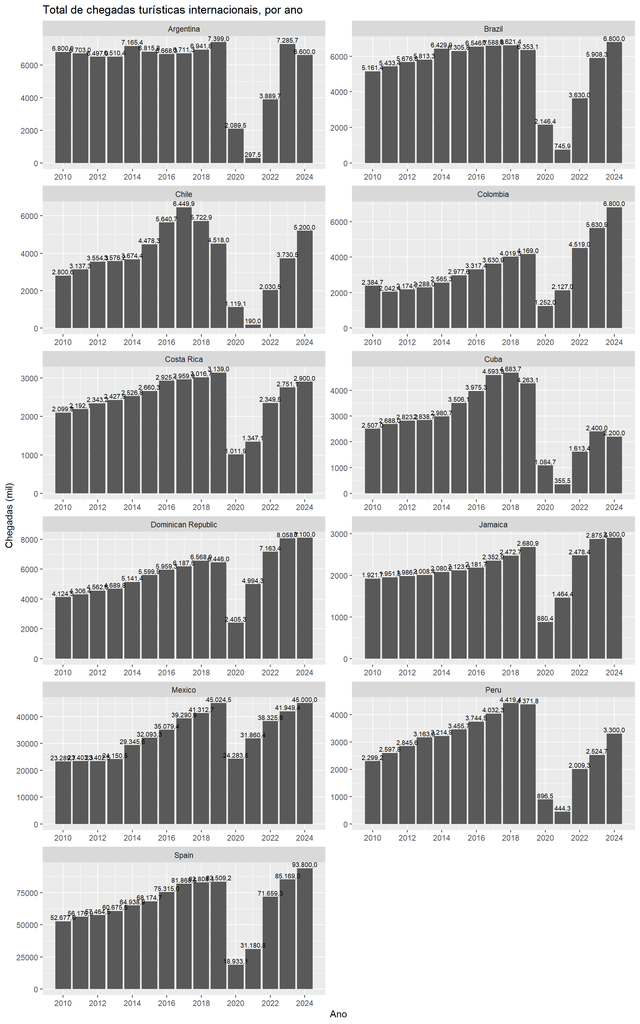

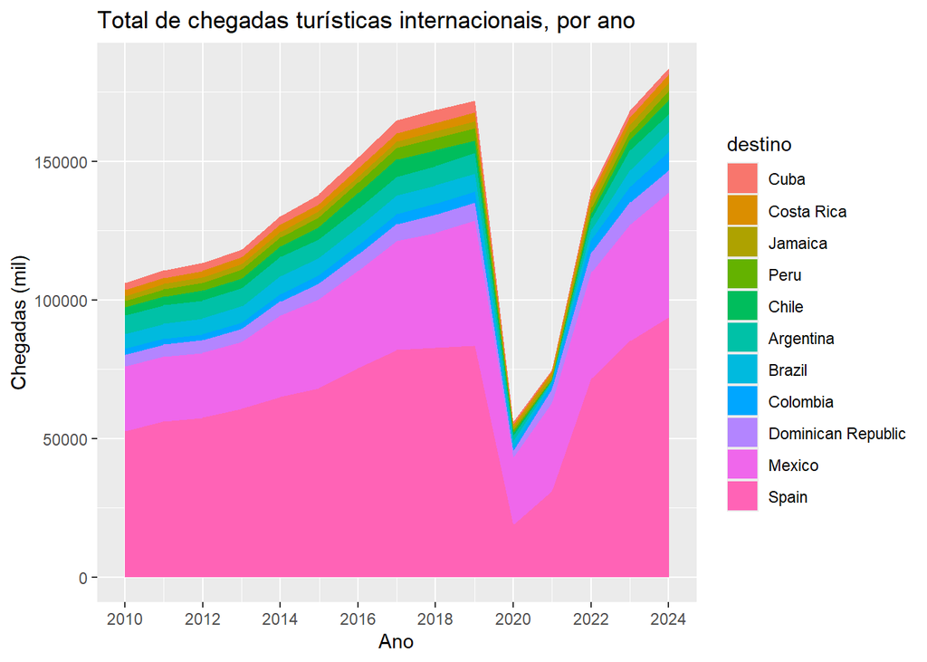

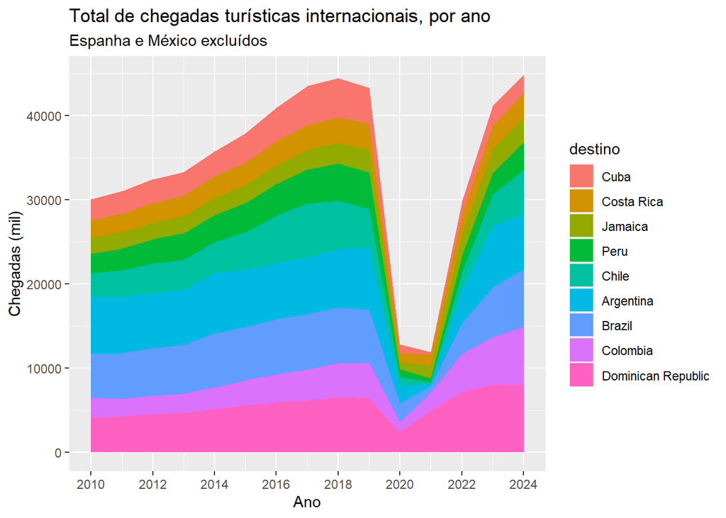

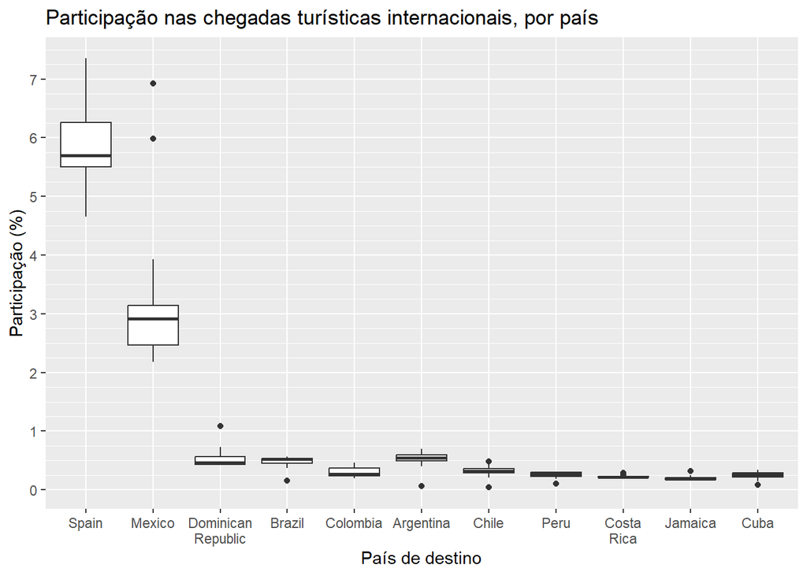

Participação nas chegadas internacionais, por país e ano (%)

| destino | 2010 | 2011 | 2012 | 2013 | 2014 | 2015 | 2016 | 2017 | 2018 | 2019 | 2020 | 2021 | 2022 | 2023 | 2024 | Média |
| --- | --- | --- | --- | --- | --- | --- | --- | --- | --- | --- | --- | --- | --- | --- | --- | --- |
| Spain | 5,41 | 5,53 | 5,42 | 5,47 | 5,64 | 5,66 | 6,04 | 6,12 | 5,85 | 5,70 | 4,66 | 6,78 | 7,35 | 6,53 | 6,40 | 5,90 |
| Mexico | 2,39 | 2,31 | 2,21 | 2,18 | 2,55 | 2,67 | 2,82 | 2,93 | 2,92 | 3,07 | 5,98 | 6,93 | 3,93 | 3,22 | 3,07 | 3,28 |
| Dominican Republic | 0,42 | 0,42 | 0,43 | 0,42 | 0,45 | 0,47 | 0,48 | 0,46 | 0,46 | 0,44 | 0,59 | 1,09 | 0,73 | 0,62 | 0,55 | 0,54 |
| Argentina | 0,70 | 0,66 | 0,61 | 0,59 | 0,62 | 0,57 | 0,54 | 0,50 | 0,49 | 0,51 | 0,51 | 0,06 | 0,40 | 0,56 | 0,45 | 0,52 |
| Brazil | 0,53 | 0,54 | 0,54 | 0,52 | 0,56 | 0,52 | 0,53 | 0,49 | 0,47 | 0,43 | 0,53 | 0,16 | 0,37 | 0,45 | 0,46 | 0,47 |
| Chile | 0,29 | 0,31 | 0,34 | 0,32 | 0,32 | 0,37 | 0,45 | 0,48 | 0,40 | 0,31 | 0,28 | 0,04 | 0,21 | 0,29 | 0,35 | 0,32 |
| Colombia | 0,25 | 0,20 | 0,21 | 0,21 | 0,22 | 0,25 | 0,27 | 0,27 | 0,28 | 0,28 | 0,31 | 0,46 | 0,46 | 0,43 | 0,46 | 0,30 |
| Peru | 0,24 | 0,26 | 0,27 | 0,29 | 0,28 | 0,29 | 0,30 | 0,30 | 0,31 | 0,30 | 0,22 | 0,10 | 0,21 | 0,19 | 0,23 | 0,25 |
| Cuba | 0,26 | 0,26 | 0,27 | 0,26 | 0,26 | 0,29 | 0,32 | 0,34 | 0,33 | 0,29 | 0,27 | 0,08 | 0,17 | 0,18 | 0,15 | 0,25 |
| Costa Rica | 0,22 | 0,22 | 0,22 | 0,22 | 0,22 | 0,22 | 0,23 | 0,22 | 0,21 | 0,21 | 0,25 | 0,29 | 0,24 | 0,21 | 0,20 | 0,23 |
| Jamaica | 0,20 | 0,19 | 0,19 | 0,18 | 0,18 | 0,18 | 0,18 | 0,18 | 0,17 | 0,18 | 0,22 | 0,32 | 0,25 | 0,22 | 0,20 | 0,20 |

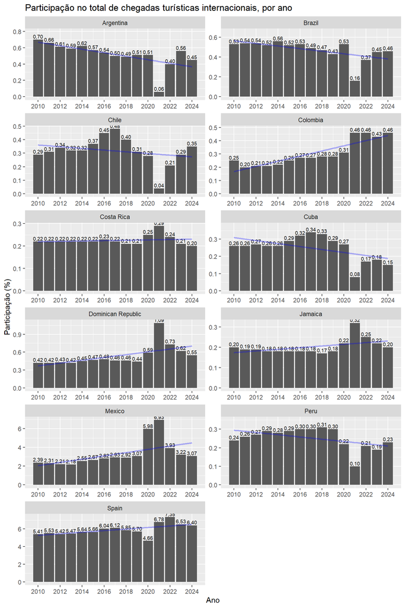

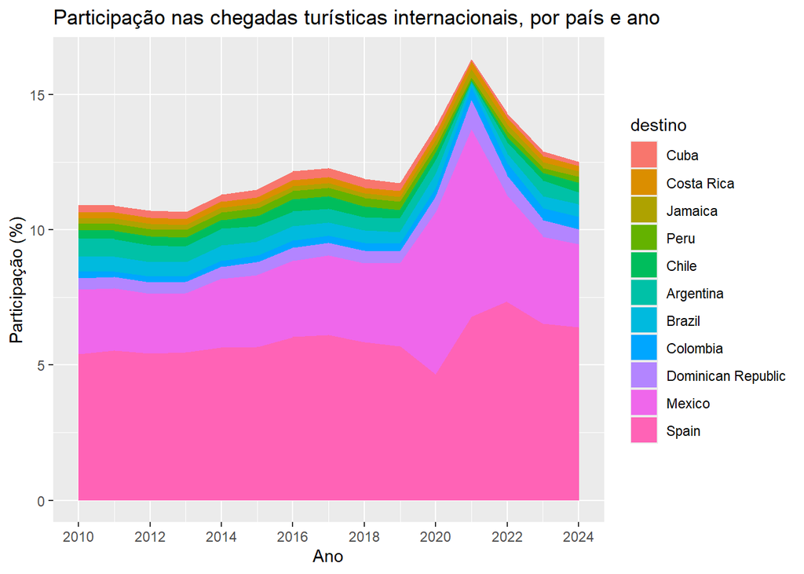

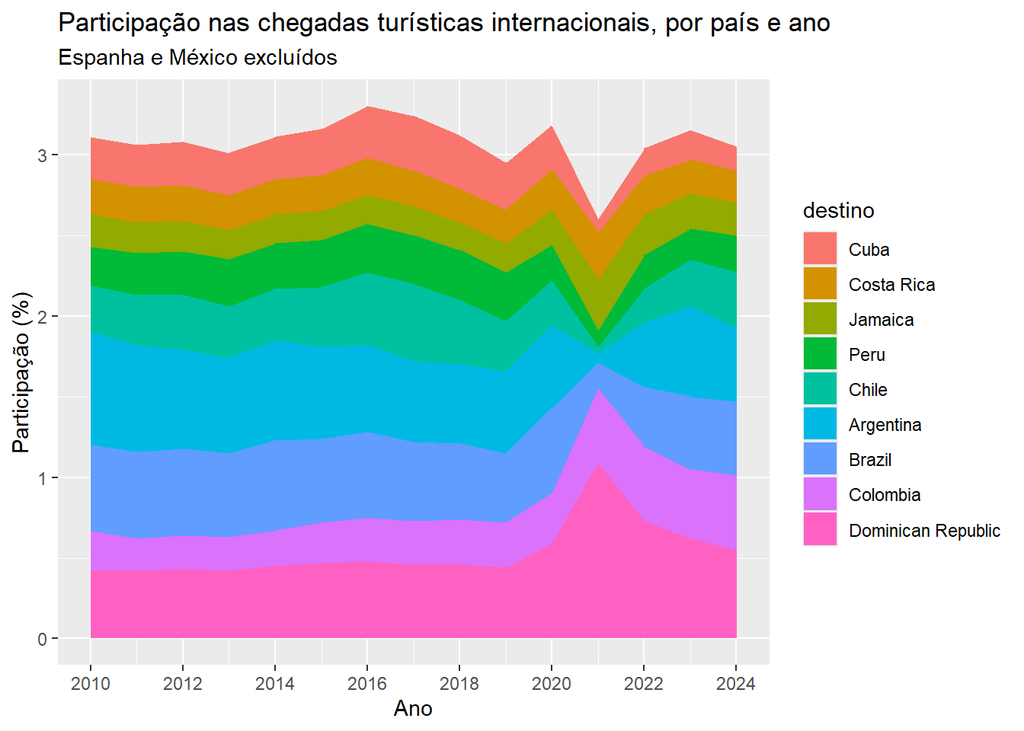

### 3.2 Decomposição da participação do Brasil e seus principais concorrentes no receptivo turístico internacional

#### 3.2.1 Brasil

Resultados SSA Brasil

| ano | brazil_volume | share_global_pct | var_share_pp | g_world_gdp | g_mundo_turismo | g_grupo_turismo | g_brazil_turismo | GGE | GIME_Mundo | GCSE_Mundo | GIME_Grupo | GCSE_Grupo |
| --- | --- | --- | --- | --- | --- | --- | --- | --- | --- | --- | --- | --- |
| 2010 | 5161.379 | 0.5305659 | -0.0077749 | 0.0452424 | 0.0905901 | 0.0496458 | 0.0748394 | 217.2540 | 217.75951 | -75.634531 | 21.14517 | 120.97981 |
| 2011 | 5433.354 | 0.5352629 | 0.0046970 | 0.0333900 | 0.0434568 | 0.0430545 | 0.0526943 | 172.3386 | 51.95837 | 47.678015 | 49.88174 | 49.75465 |
| 2012 | 5676.843 | 0.5354442 | 0.0001813 | 0.0273121 | 0.0444600 | 0.0243898 | 0.0448138 | 148.3963 | 93.17076 | 1.921945 | -15.87785 | 110.97055 |
| 2013 | 5813.342 | 0.5243966 | -0.0110476 | 0.0288814 | 0.0456187 | 0.0424587 | 0.0240449 | 163.9553 | 95.01506 | -122.471346 | 77.07612 | -104.53241 |
| 2014 | 6429.852 | 0.5584529 | 0.0340564 | 0.0313302 | 0.0386001 | 0.1009040 | 0.1060509 | 182.1330 | 42.26244 | 392.114534 | 404.45617 | 29.92081 |
| 2015 | 6305.838 | 0.5236803 | -0.0347727 | 0.0311379 | 0.0458327 | 0.0624852 | -0.0192872 | 200.2120 | 94.48547 | -418.711503 | 201.55874 | -525.78477 |
| 2016 | 6546.696 | 0.5253582 | 0.0016780 | 0.0279359 | 0.0348801 | 0.0952511 | 0.0381960 | 176.1594 | 43.78889 | 20.909719 | 424.47847 | -359.77986 |
| 2017 | 6588.770 | 0.4921716 | -0.0331866 | 0.0345183 | 0.0742890 | 0.0879642 | 0.0064268 | 225.9808 | 260.36691 | -444.273733 | 349.89379 | -533.80061 |
| 2018 | 6621.376 | 0.4678709 | -0.0243007 | 0.0327396 | 0.0571446 | 0.0238127 | 0.0049487 | 215.7136 | 160.79922 | -343.906800 | -58.81708 | -124.29050 |
| 2019 | 6353.141 | 0.4336721 | -0.0341989 | 0.0267912 | 0.0351537 | 0.0194885 | -0.0405105 | 177.3944 | 55.37173 | -501.001183 | -48.35380 | -397.27565 |
| 2020 | 2146.435 | 0.5281962 | 0.0945241 | -0.0289922 | -0.7226070 | -0.6735824 | -0.6621459 | -184.1917 | -4406.63268 | 384.118415 | -4095.17192 | 72.65765 |
| 2021 | 745.871 | 0.1622610 | -0.3659352 | 0.0641335 | 0.1311682 | 0.3369642 | -0.6525071 | 137.6584 | 143.88557 | -1682.107949 | 585.61342 | -2123.83580 |
| 2022 | 3630.031 | 0.3723633 | 0.2101023 | 0.0340305 | 1.1207710 | 0.8620628 | 3.8668349 | 25.3824 | 810.56820 | 2048.209403 | 617.60526 | 2241.17234 |
| 2023 | 5908.341 | 0.4528983 | 0.0805350 | 0.0294859 | 0.3382012 | 0.2048851 | 0.6276282 | 107.0349 | 1120.64606 | 1050.629033 | 636.70425 | 1534.57085 |
| 2024 | 6800.000 | 0.4641638 | 0.0112655 | 0.0287195 | 0.1229819 | 0.0910131 | 0.1509153 | 169.6846 | 556.93436 | 165.040065 | 368.05183 | 353.92259 |

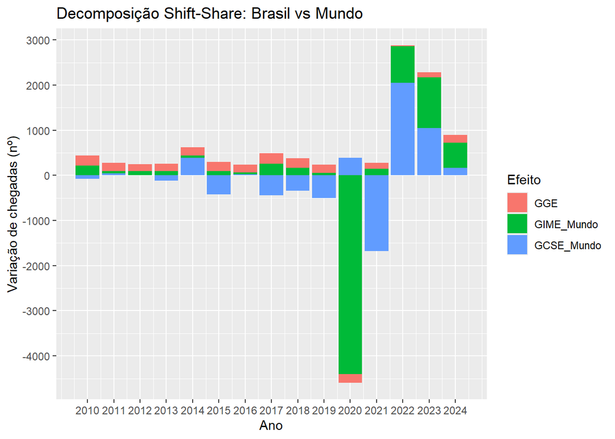

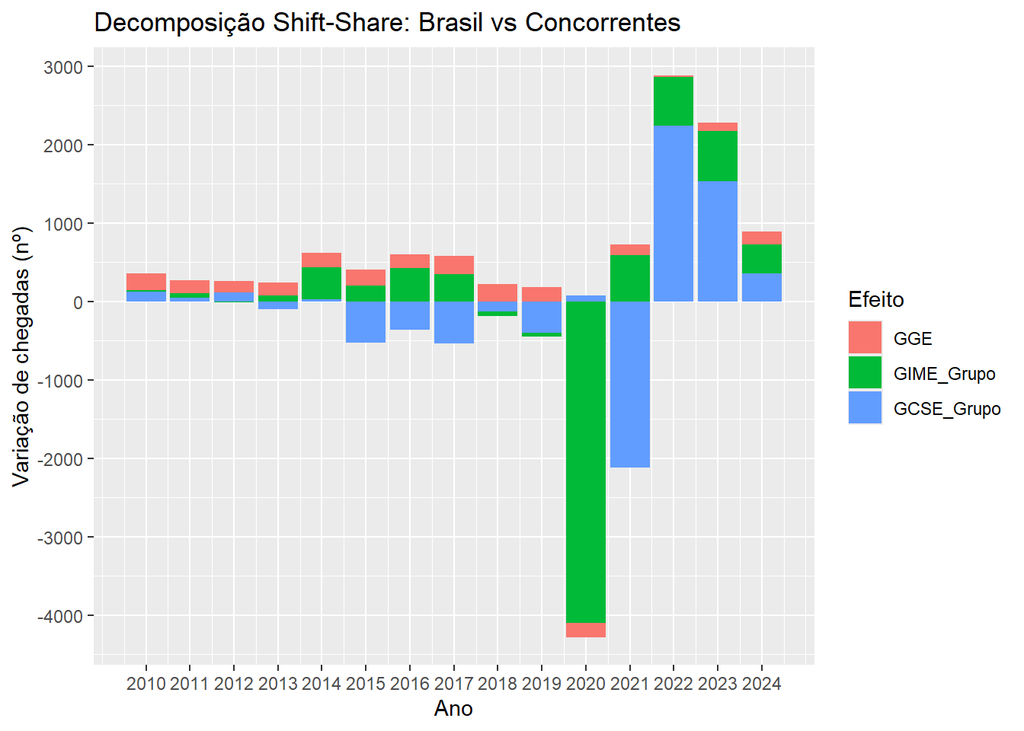

#### 3.2.2 Brasil x Concorrentes

Resumo Geral

| destino | Volume_Inicial | Volume_Final | Variação_Total | Share_Global_Inicial | Share_Global_Final | Variação_Share_PP | Total_GGE | Total_GIME_Mundo | Total_GCSE_Mundo | Total_GIME_Grupo | Total_GCSE_Grupo |
| --- | --- | --- | --- | --- | --- | --- | --- | --- | --- | --- | --- |
| Chile | 2760 | 5200 | 2440 | 0.3094170 | 0.3549488 | 0.0455318 | 1431.7420 | -1066.3819 | 2074.6399 | -915.1714 | 1923.4294 |
| Argentina | 4308 | 6600 | 2292 | 0.4829596 | 0.4505119 | -0.0324477 | 2299.5997 | -1606.6578 | 1599.0581 | -1281.3605 | 1273.7608 |
| Colombia | 2364 | 6800 | 4436 | 0.2650224 | 0.4641638 | 0.1991414 | 1207.7602 | 1961.3823 | 1266.8575 | 1171.4722 | 2056.7676 |
| Peru | 2140 | 3300 | 1160 | 0.2399103 | 0.2252560 | -0.0146543 | 1079.7815 | -1040.2006 | 1120.4191 | -947.7447 | 1027.9632 |
| Brazil | 4802 | 6800 | 1998 | 0.5383408 | 0.4641638 | -0.0741770 | 2135.1060 | -659.6201 | 522.5141 | -481.7557 | 344.6497 |
| Cuba | 2405 | 2200 | -205 | 0.2696188 | 0.1501706 | -0.1194482 | 1114.8328 | -1147.7906 | -172.0421 | -995.6646 | -324.1682 |
| Costa Rica | 1923 | 2900 | 977 | 0.2155830 | 0.1979522 | -0.0176307 | 960.4404 | 811.3394 | -794.7798 | 540.8564 | -524.2968 |
| Jamaica | 1831 | 2900 | 1069 | 0.2052691 | 0.1979522 | -0.0073168 | 847.4989 | 1220.9522 | -999.4510 | 811.8018 | -590.3007 |
| Dominican Republic | 3992 | 8100 | 4108 | 0.4475336 | 0.5529010 | 0.1053674 | 2195.4475 | 5053.0211 | -3140.4686 | 3581.6134 | -1669.0610 |
| Spain | 52178 | 93800 | 41622 | 5.8495516 | 6.4027304 | 0.5531788 | 25052.8714 | 19758.1550 | -3189.0264 | 9920.4253 | 6648.7033 |
| Mexico | 22346 | 45000 | 22654 | 2.5051570 | 3.0716724 | 0.5665154 | 12945.8322 | 26378.1017 | -16669.9339 | 19875.6151 | -10167.4473 |
| Concorrentes | 96247 | 176800 | 80553 | 10.7900224 | 12.0682594 | 1.2782370 | 49135.8066 | 50321.9207 | -18904.7272 | 31761.8431 | -344.6497 |

## 4 Participação dos países prioritários e sensíveis às mudanças climáticas no Turismo Internacional

### 4.1 Evolução da participação dos mercados selecionados no emissivo mundial

#### 4.1.1 Principais emissores mundiais

- As medições de turismo emissivo internacional são menos confiáveis do que as de turismo receptivo, devido ao desinteresse dos países pela medição. E parecem que questão ainda piores depois de 2019.
- O gráfico a seguir dá uma dimensão dos principais emissores mundiais. A partir da soma dos resultados do período de 2010 a 2024, o gráfico apresenta o percentual relativo aos 20 países mais relevantes.

[figure not shown]

#### 4.1.2 Principais emissores do Brasil

| pais | 2010 | 2011 | 2012 | 2013 | 2014 | 2015 | 2016 | 2017 | 2018 | 2019 | 2020 | 2021 | 2022 | 2023 | 2024 | Média |
| --- | --- | --- | --- | --- | --- | --- | --- | --- | --- | --- | --- | --- | --- | --- | --- | --- |
| Argentina | 1.399.592,0 | 1.593.775,0 | 1.671.604,0 | 1.711.491,0 | 1.743.930,0 | 2.079.823,0 | 2.294.900,0 | 2.622.327,0 | 2.498.483,0 | 1.954.725,0 | 887.805,0 | 67.280,0 | 1.032.762,0 | 1.882.240,0 | 1.960.182,0 | 1.693.394,6 |
| Estados Unidos | 641.377,0 | 594.947,0 | 586.463,0 | 592.827,0 | 656.801,0 | 575.796,0 | 570.350,0 | 475.232,0 | 538.532,0 | 590.520,0 | 172.105,0 | 132.182,0 | 441.007,0 | 668.478,0 | 728.537,0 | 531.010,3 |
| Chile | 200.724,0 | 217.200,0 | 250.586,0 | 268.203,0 | 336.950,0 | 306.331,0 | 311.813,0 | 342.143,0 | 387.470,0 | 391.689,0 | 131.174,0 | 46.673,0 | 202.470,0 | 458.576,0 | 653.895,0 | 300.393,1 |
| Paraguai | 194.340,0 | 192.730,0 | 246.401,0 | 268.932,0 | 293.841,0 | 301.831,0 | 316.714,0 | 336.646,0 | 356.897,0 | 406.526,0 | 122.981,0 | 132.126,0 | 308.234,0 | 424.460,0 | 465.020,0 | 291.178,6 |
| Uruguai | 228.545,0 | 261.204,0 | 253.864,0 | 262.512,0 | 223.508,0 | 267.321,0 | 284.113,0 | 328.098,0 | 348.336,0 | 364.830,0 | 113.714,0 | 11.575,0 | 180.064,0 | 334.703,0 | 388.464,0 | 256.723,4 |
| França | 199.719,0 | 207.890,0 | 218.626,0 | 224.078,0 | 282.375,0 | 261.075,0 | 263.774,0 | 254.153,0 | 238.345,0 | 257.504,0 | 70.369,0 | 34.848,0 | 130.910,0 | 187.559,0 | 235.163,0 | 204.425,9 |
| Alemanha | 226.630,0 | 241.739,0 | 258.437,0 | 236.505,0 | 265.498,0 | 224.549,0 | 221.513,0 | 203.045,0 | 209.039,0 | 206.882,0 | 61.149,0 | 29.514,0 | 120.670,0 | 158.582,0 | 182.166,0 | 189.727,9 |
| Itália | 245.491,0 | 229.484,0 | 230.114,0 | 233.243,0 | 228.734,0 | 202.015,0 | 181.493,0 | 171.654,0 | 175.763,0 | 182.587,0 | 45.646,0 | 18.907,0 | 86.766,0 | 129.447,0 | 154.495,0 | 167.722,6 |
| Portugal | 189.065,0 | 183.728,0 | 168.649,0 | 168.250,0 | 170.066,0 | 162.305,0 | 149.968,0 | 144.095,0 | 145.816,0 | 176.229,0 | 51.028,0 | 38.704,0 | 149.747,0 | 182.463,0 | 218.354,0 | 153.231,1 |
| Reino Unido | 167.355,0 | 149.564,0 | 155.548,0 | 169.732,0 | 217.003,0 | 189.269,0 | 202.671,0 | 185.858,0 | 154.586,0 | 163.425,0 | 48.595,0 | 9.809,0 | 87.909,0 | 130.239,0 | 153.754,0 | 145.687,8 |
| Espanha | 179.340,0 | 190.392,0 | 180.406,0 | 169.751,0 | 166.759,0 | 151.029,0 | 147.846,0 | 137.202,0 | 147.159,0 | 145.325,0 | 32.665,0 | 22.828,0 | 83.745,0 | 114.096,0 | 132.484,0 | 133.401,8 |
| Colômbia | 85.567,0 | 91.345,0 | 100.324,0 | 116.461,0 | 158.886,0 | 118.866,0 | 135.192,0 | 140.363,0 | 131.596,0 | 126.595,0 | 27.129,0 | 27.892,0 | 84.470,0 | 118.163,0 | 129.501,0 | 106.156,7 |
| Bolívia | 99.359,0 | 85.429,0 | 112.639,0 | 95.028,0 | 95.300,0 | 108.149,0 | 138.106,0 | 126.781,0 | 126.253,0 | 132.069,0 | 45.449,0 | 26.330,0 | 90.694,0 | 123.803,0 | 129.992,0 | 102.358,7 |
| Peru | 81.020,0 | 86.795,0 | 91.996,0 | 98.602,0 | 117.230,0 | 113.078,0 | 114.276,0 | 115.320,0 | 121.326,0 | 135.880,0 | 33.895,0 | 13.077,0 | 61.634,0 | 99.353,0 | 131.368,0 | 94.323,3 |
| México | 67.616,0 | 64.451,0 | 61.658,0 | 76.738,0 | 109.637,0 | 90.361,0 | 94.609,0 | 81.778,0 | 79.891,0 | 82.921,0 | 18.068,0 | 12.731,0 | 52.171,0 | 82.324,0 | 99.137,0 | 71.606,1 |
| Canadá | 64.188,0 | 70.358,0 | 68.462,0 | 67.610,0 | 78.531,0 | 68.293,0 | 70.103,0 | 48.951,0 | 71.160,0 | 77.043,0 | 26.950,0 | 8.077,0 | 54.252,0 | 86.591,0 | 96.540,0 | 63.807,3 |
| Suíça | 69.995,0 | 65.951,0 | 69.571,0 | 68.390,0 | 80.277,0 | 70.319,0 | 69.074,0 | 69.484,0 | 70.040,0 | 63.826,0 | 17.063,0 | 13.568,0 | 38.371,0 | 50.359,0 | 58.092,0 | 58.292,0 |
| Japão | 59.742,0 | 63.247,0 | 73.102,0 | 87.225,0 | 84.636,0 | 70.102,0 | 79.754,0 | 60.342,0 | 63.708,0 | 78.914,0 | 20.476,0 | 1.904,0 | 17.635,0 | 42.341,0 | 61.129,0 | 57.617,1 |
| Holanda | 76.411,0 | 72.162,0 | 73.133,0 | 69.187,0 | 81.655,0 | 66.870,0 | 72.268,0 | 59.272,0 | 62.651,0 | 59.752,0 | 16.532,0 | 9.080,0 | 35.488,0 | 45.917,0 | 54.273,0 | 56.976,7 |
| China | 37.849,0 | 55.978,0 | 65.945,0 | 60.140,0 | 57.502,0 | 53.064,0 | 57.860,0 | 61.250,0 | 56.333,0 | 68.578,0 | 6.297,0 | 2.360,0 | 8.787,0 | 42.542,0 | 76.524,0 | 47.400,6 |

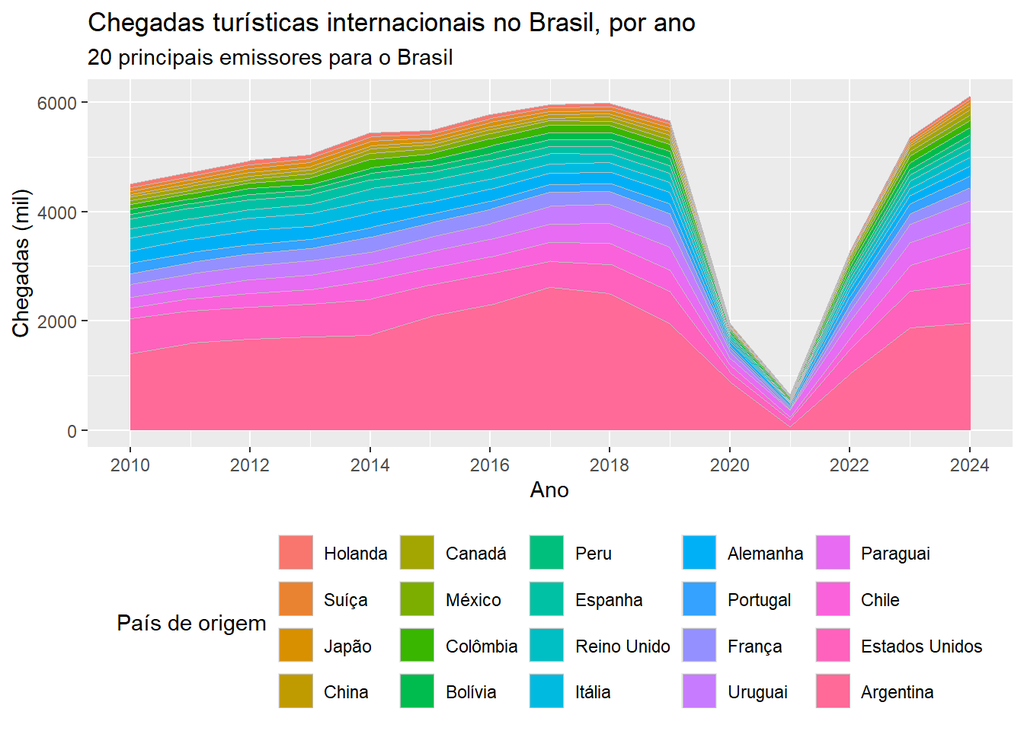

Variação anual das chegadas turísticas internacionais ao Brasil, por país e ano (mil)

20 principais emissores para o Brasil

| pais | 2010 | 2011 | 2012 | 2013 | 2014 | 2015 | 2016 | 2017 | 2018 | 2019 | 2020 | 2021 | 2022 | 2023 | 2024 |
| --- | --- | --- | --- | --- | --- | --- | --- | --- | --- | --- | --- | --- | --- | --- | --- |
| Alemanha | 5,1 | 6,7 | 6,9 | −8,5 | 12,3 | −15,4 | −1,4 | −8,3 | 3,0 | −1,0 | −70,4 | −51,7 | 308,9 | 31,4 | 14,9 |
| Argentina | 15,6 | 13,9 | 4,9 | 2,4 | 1,9 | 19,3 | 10,3 | 14,3 | −4,7 | −21,8 | −54,6 | −92,4 | 1.435,0 | 82,3 | 4,1 |
| Bolívia | 19,1 | −14,0 | 31,9 | −15,6 | 0,3 | 13,5 | 27,7 | −8,2 | −0,4 | 4,6 | −65,6 | −42,1 | 244,5 | 36,5 | 5,0 |
| Canadá | 1,4 | 9,6 | −2,7 | −1,2 | 16,2 | −13,0 | 2,7 | −30,2 | 45,4 | 8,3 | −65,0 | −70,0 | 571,7 | 59,6 | 11,5 |
| Chile | 17,7 | 8,2 | 15,4 | 7,0 | 25,6 | −9,1 | 1,8 | 9,7 | 13,2 | 1,1 | −66,5 | −64,4 | 333,8 | 126,5 | 42,6 |
| China | 34,1 | 47,9 | 17,8 | −8,8 | −4,4 | −7,7 | 9,0 | 5,9 | −8,0 | 21,7 | −90,8 | −62,5 | 272,3 | 384,1 | 79,9 |
| Colômbia | 9,7 | 6,8 | 9,8 | 16,1 | 36,4 | −25,2 | 13,7 | 3,8 | −6,2 | −3,8 | −78,6 | 2,8 | 202,8 | 39,9 | 9,6 |
| Espanha | 2,8 | 6,2 | −5,2 | −5,9 | −1,8 | −9,4 | −2,1 | −7,2 | 7,3 | −1,2 | −77,5 | −30,1 | 266,9 | 36,2 | 16,1 |
| Estados Unidos | 6,2 | −7,2 | −1,4 | 1,1 | 10,8 | −12,3 | −0,9 | −16,7 | 13,3 | 9,7 | −70,9 | −23,2 | 233,6 | 51,6 | 9,0 |
| França | −3,0 | 4,1 | 5,2 | 2,5 | 26,0 | −7,5 | 1,0 | −3,6 | −6,2 | 8,0 | −72,7 | −50,5 | 275,7 | 43,3 | 25,4 |
| Holanda | 1,2 | −5,6 | 1,3 | −5,4 | 18,0 | −18,1 | 8,1 | −18,0 | 5,7 | −4,6 | −72,3 | −45,1 | 290,8 | 29,4 | 18,2 |
| Itália | −3,2 | −6,5 | 0,3 | 1,4 | −1,9 | −11,7 | −10,2 | −5,4 | 2,4 | 3,9 | −75,0 | −58,6 | 358,9 | 49,2 | 19,4 |
| Japão | −10,4 | 5,9 | 15,6 | 19,3 | −3,0 | −17,2 | 13,8 | −24,3 | 5,6 | 23,9 | −74,1 | −90,7 | 826,2 | 140,1 | 44,4 |
| México | −0,6 | −4,7 | −4,3 | 24,5 | 42,9 | −17,6 | 4,7 | −13,6 | −2,3 | 3,8 | −78,2 | −29,5 | 309,8 | 57,8 | 20,4 |
| Paraguai | 7,7 | −0,8 | 27,8 | 9,1 | 9,3 | 2,7 | 4,9 | 6,3 | 6,0 | 13,9 | −69,7 | 7,4 | 133,3 | 37,7 | 9,6 |
| Peru | 2,6 | 7,1 | 6,0 | 7,2 | 18,9 | −3,5 | 1,1 | 0,9 | 5,2 | 12,0 | −75,1 | −61,4 | 371,3 | 61,2 | 32,2 |
| Portugal | 2,9 | −2,8 | −8,2 | −0,2 | 1,1 | −4,6 | −7,6 | −3,9 | 1,2 | 20,9 | −71,0 | −24,2 | 286,9 | 21,8 | 19,7 |
| Reino Unido | −3,1 | −10,6 | 4,0 | 9,1 | 27,9 | −12,8 | 7,1 | −8,3 | −16,8 | 5,7 | −70,3 | −79,8 | 796,2 | 48,2 | 18,1 |
| Suíça | −3,8 | −5,8 | 5,5 | −1,7 | 17,4 | −12,4 | −1,8 | 0,6 | 0,8 | −8,9 | −73,3 | −20,5 | 182,8 | 31,2 | 15,4 |
| Uruguai | 20,7 | 14,3 | −2,8 | 3,4 | −14,9 | 19,6 | 6,3 | 15,5 | 6,2 | 4,7 | −68,8 | −89,8 | 1.455,6 | 85,9 | 16,1 |

#### 4.1.3 Mercados selecionados: quem são, quanto representam e quanto cresceram

##### 4.1.3.1 Quem são?

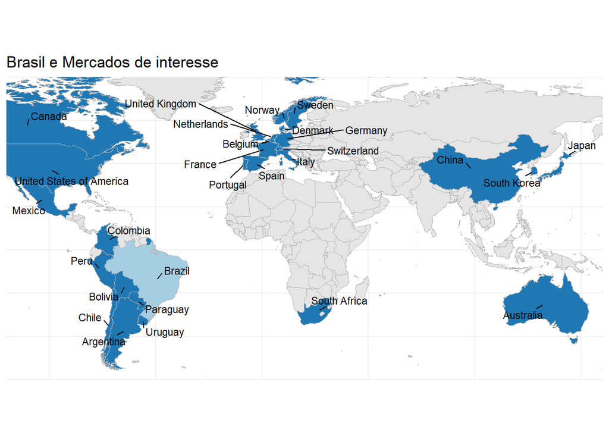

##### 4.1.3.2 Quanto representam do total?

- Os mercados selecionados representam mais de 40% do total mundial de partidas.
  - A média entre 2010 e 2019 é de 41.2 %.
  - A média entre 2010 e 2024 é de 39.2 %.
- A queda pós-pandemia muito provavelmente é por conta de ausência de dados.

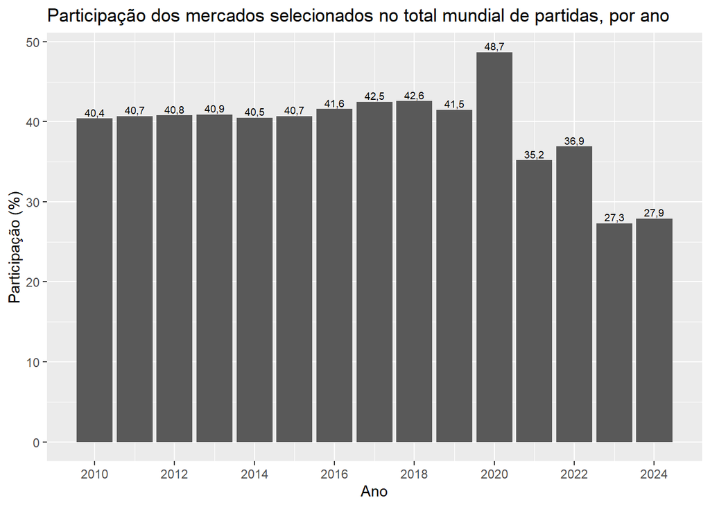

##### 4.1.3.3 Como foi sua evolução ao longo do tempo?

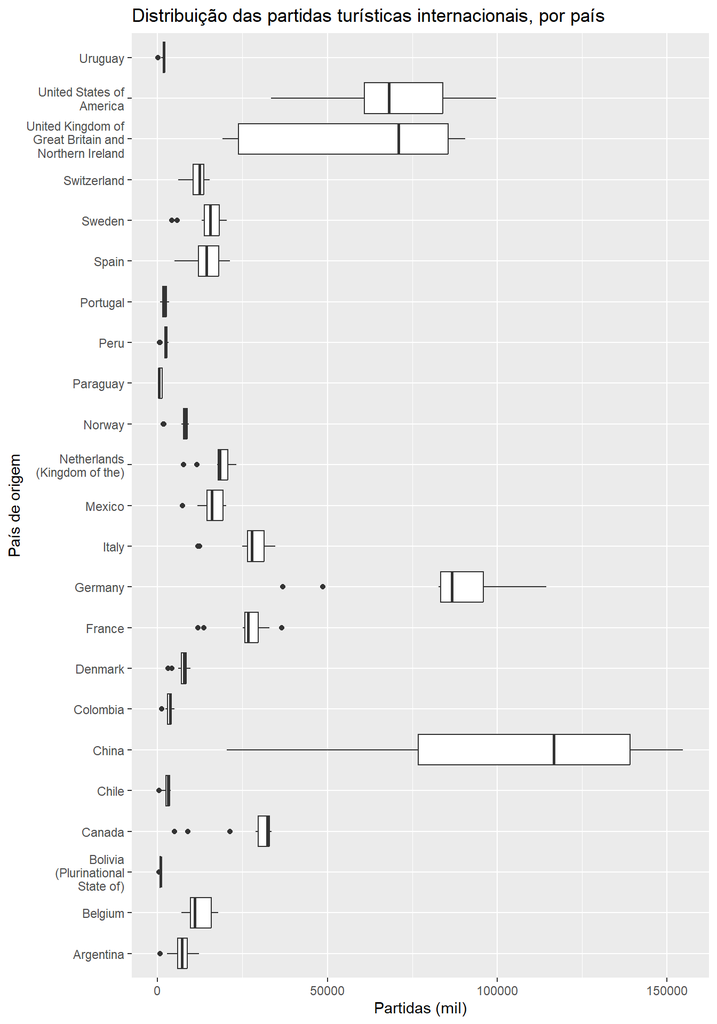

Partidas turísticas internacionais, por país e ano (mil)

| origem | 2010 | 2011 | 2012 | 2013 | 2014 | 2015 | 2016 | 2017 | 2018 | 2019 | 2020 | 2021 | 2022 | 2023 | 2024 | Média |
| --- | --- | --- | --- | --- | --- | --- | --- | --- | --- | --- | --- | --- | --- | --- | --- | --- |
| China | 57.386 | 70.250 | 83.182 | 98.185 | 116.593 | 127.860 | 135.130 | 143.035 | 149.720 | 154.632 | 20.334 | NA | NA | NA | NA | 105.119 |
| Germany | 85.872 | 84.692 | 82.729 | 87.459 | 83.008 | 83.737 | 90.966 | 92.402 | 108.542 | 99.533 | 36.867 | 48.667 | 86.623 | 102.058 | 114.397 | 85.837 |
| United States of America | 61.061 | 59.209 | 60.697 | 61.344 | 68.185 | 74.191 | 80.223 | 87.657 | 93.137 | 99.744 | 33.499 | NA | NA | NA | NA | 70.813 |
| United Kingdom of Great Britain and Northern Ireland | NA | NA | NA | NA | NA | NA | NA | NA | NA | NA | 23.827 | 19.142 | 70.950 | 85.530 | 90.610 | 58.012 |
| Canada | 28.893 | 30.445 | 32.267 | 32.996 | 33.526 | 32.265 | 31.278 | 32.730 | 33.440 | 33.064 | 8.971 | 4.954 | 21.400 | 30.346 | 33.091 | 27.978 |
| Italy | 28.188 | 27.831 | 27.376 | 26.305 | 26.862 | 27.494 | 29.067 | 31.805 | 33.347 | 34.703 | 11.960 | 12.354 | 24.970 | 30.990 | 34.585 | 27.189 |
| France | 25.041 | 26.155 | 25.317 | 26.062 | 27.919 | 26.648 | 26.483 | 29.055 | 30.509 | 30.407 | 11.937 | 13.681 | 28.085 | 33.018 | 36.522 | 26.456 |
| Netherlands (Kingdom of the) | 18.368 | 18.560 | 18.628 | 18.094 | 17.928 | 17.535 | 18.152 | 20.763 | 20.981 | 22.045 | 7.667 | 11.601 | 23.146 | NA | NA | 17.959 |
| Mexico | 14.334 | 14.799 | 15.581 | 15.911 | 18.261 | 19.603 | 20.223 | 19.067 | 19.748 | 19.810 | 7.345 | 11.685 | 13.750 | 16.000 | 18.817 | 16.329 |
| Sweden | 13.042 | 14.651 | 15.548 | 15.917 | NA | NA | NA | 20.361 | 18.855 | 18.000 | 4.225 | 5.767 | 15.467 | NA | 18.345 | 14.562 |
| Spain | 12.379 | 13.347 | 12.422 | 11.246 | 11.783 | 14.407 | 15.405 | 17.031 | 19.032 | 19.845 | 4.940 | 7.013 | 15.755 | 18.950 | 21.286 | 14.323 |
| Belgium | 8.801 | 9.727 | 9.576 | 10.803 | 10.991 | 10.835 | 13.372 | 14.628 | 15.627 | 17.321 | 7.108 | 8.593 | 16.005 | 17.297 | 17.914 | 12.573 |
| Switzerland | 10.011 | 10.466 | 12.098 | 12.403 | 12.518 | 13.601 | 13.857 | 15.318 | 15.285 | 13.443 | 6.118 | 6.296 | 11.275 | NA | NA | 11.745 |
| Norway | 7.590 | 8.130 | 9.250 | 9.280 | 9.190 | 8.750 | 8.030 | 8.170 | 8.110 | 8.890 | 1.690 | 1.860 | 7.040 | 7.630 | 8.410 | 7.468 |
| Denmark | 7.726 | 7.846 | 7.843 | 6.977 | 8.528 | 8.991 | 9.651 | 8.087 | 7.475 | 9.088 | 4.230 | 3.182 | 6.043 | NA | NA | 7.359 |
| Argentina | 5.307 | 6.686 | 7.266 | 6.746 | 6.517 | 7.807 | 10.417 | 12.213 | 11.130 | 9.114 | 2.841 | 833 | 5.142 | 7.437 | 8.314 | 7.185 |
| Colombia | 2.342 | 2.522 | 3.169 | 3.605 | 3.911 | 3.862 | 3.795 | 4.017 | 4.368 | 4.479 | 1.275 | 3.004 | 4.931 | NA | NA | 3.483 |
| Chile | 2.219 | 2.638 | 2.837 | 2.999 | 3.169 | 3.359 | 3.553 | 3.620 | 3.825 | 3.346 | 963 | 514 | 2.155 | 3.758 | 3.681 | 2.842 |
| Peru | 2.058 | 2.132 | 2.296 | 2.364 | 2.442 | 2.595 | 2.751 | 2.875 | 3.078 | 3.275 | 791 | 617 | 2.118 | NA | NA | 2.261 |
| Portugal | NA | NA | 1.361 | 1.490 | 1.502 | 1.893 | 1.941 | 2.195 | 2.486 | 3.100 | 680 | 1.012 | 2.657 | 3.228 | 3.430 | 2.075 |
| Uruguay | 1.027 | 1.534 | 1.816 | 2.281 | 2.396 | 2.217 | 1.715 | 1.789 | 1.947 | 2.199 | NA | 93 | NA | NA | NA | 1.729 |
| Bolivia (Plurinational State of) | 604 | 775 | 788 | 837 | 932 | 965 | 940 | 997 | 1.060 | 1.160 | 432 | 376 | 821 | NA | NA | 822 |
| Paraguay | 302 | 347 | 400 | 440 | 426 | 1.008 | 1.503 | 1.471 | 1.447 | 1.449 | 378 | 366 | 988 | NA | NA | 810 |

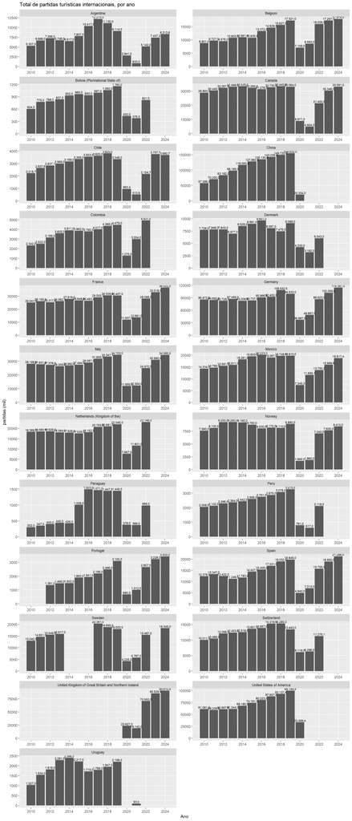

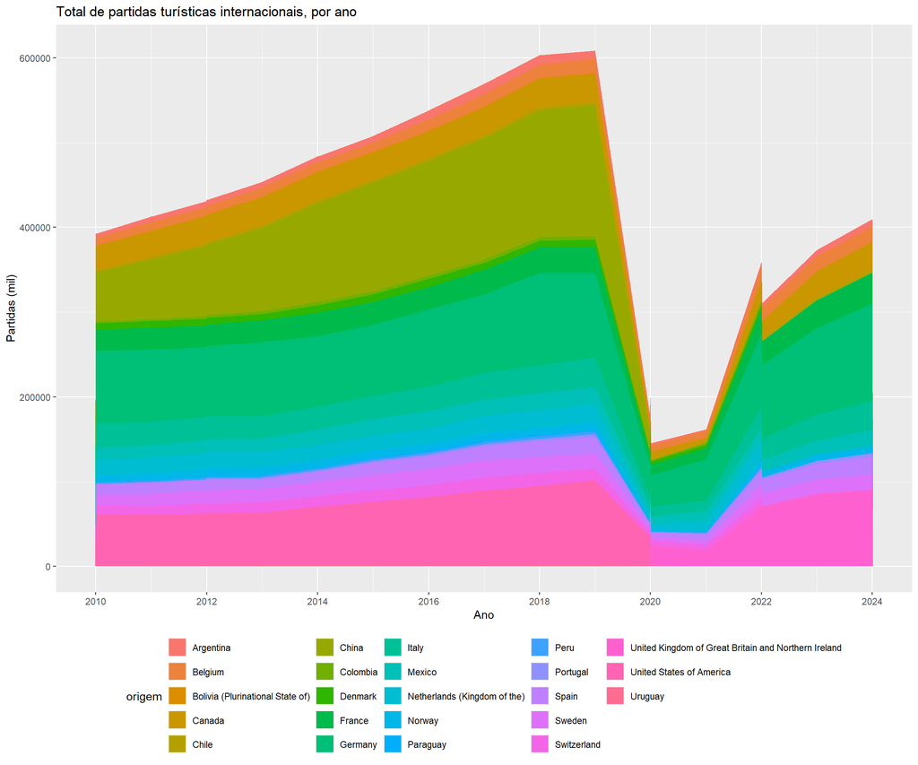

### 4.2 Decomposição da participação dos mercados selecionados no emissivo turístico internacional

### 4.3 Evolução da participação do Brasil no emissivo internacional dos mercados selecionados